# Homework Assignment 1

Assigned: Mar 11, 2021, Due Mar 21, 2021 11:59PM

## HW-1 Instructions

> Our class emphasizes clear communication of data analysis results to non-technical audiences. I expect your HTML output documents to be readable and well formatted. I expect you to put ample comments in your R code to make the code understandable. Along with accuracy of results, I am looking for quality of presentation as well. To complete this assignment, follow these steps:
1. Download the `HW1.Rmd` file from Canvas.
2. Open `HW1.Rmd` in RStudio.
3. Replace the “Your Name Here” text in the `author:` field with names of the students in HW team - up to two students can work together on HWs. Note that each student needs to submit his/her assignment separately.
4. Supply your solutions to the homework by editing `HW1.Rmd`.
5. When you have completed the homework and have **checked** that your code both runs in the Console and knits correctly when you click `Knit HTML`, you should then submit both the RMD file and its html output.
6. Run your code in the Console and Knit HTML frequently to check for errors.
7. You may find it easier to solve a problem by interacting only with the Console at first.
8. Note - you can insert an R block for writing your R code by either clicking the **insert** button or pressing Control-Alt-I. You can knit an RMD file into its HTML output by clicking the **Knit** button or pressing “Control-Shift-K”.

We will continue working with the nycflights dataset we looked at last class. **Please be sure to keep the data file in the same directory as the RMD file.**

First - lets read the data into an object named `nyc`.

```r
nyc <- read.csv("nycflights.csv")
#Lets calculate how many rows there are
nrow(nyc)
```

```
## [1] 336776
```

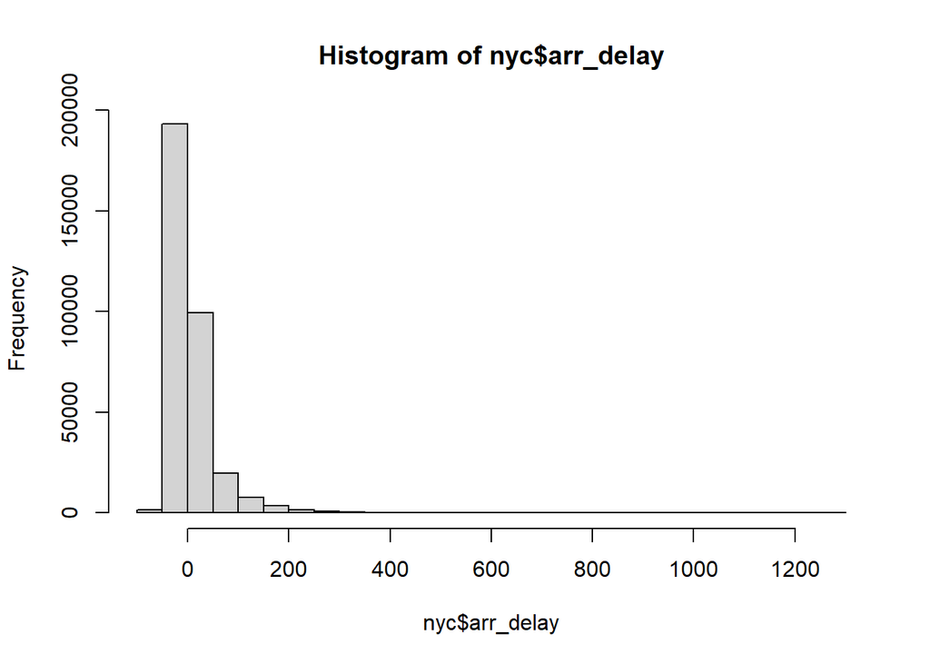

```r
hist(nyc$arr_delay)
```

Number of rows in my dataset is :336776

I now would like you to answer the following - all in their own separate R code blocks.

### Data Exploration

Let’s first do some simple exploration of this data. I would like for you to answer each of the questions below with an **inline R code** integrated into the text and not in a separate R code block.

- How many airlines are there? (Hint: `levels` and `length` can be useful here)

There are 16 different airlines in our dataset.

- How many flights there were by the airline with code `OO`? (Hint: `nrow` can be useful here along with logical indexing)

```r
#LOgical indexing

nycoo <- nyc[  nyc$carrier =="OO","carrier"   ]
length(nycoo)
```

```
## [1] 32
```

```r
#Simple logical Indexing
nyc[c(1,2,3:10),]
```

```
##     X year month day dep_time sched_dep_time dep_delay arr_time sched_arr_time
## 1   1 2013     1   1      517            515         2      830            819
## 2   2 2013     1   1      533            529         4      850            830
## 3   3 2013     1   1      542            540         2      923            850
## 4   4 2013     1   1      544            545        -1     1004           1022
## 5   5 2013     1   1      554            600        -6      812            837
## 6   6 2013     1   1      554            558        -4      740            728
## 7   7 2013     1   1      555            600        -5      913            854
## 8   8 2013     1   1      557            600        -3      709            723
## 9   9 2013     1   1      557            600        -3      838            846
## 10 10 2013     1   1      558            600        -2      753            745
##    arr_delay carrier flight tailnum origin dest air_time distance hour minute
## 1         11      UA   1545  N14228    EWR  IAH      227     1400    5     15
## 2         20      UA   1714  N24211    LGA  IAH      227     1416    5     29
## 3         33      AA   1141  N619AA    JFK  MIA      160     1089    5     40
```

[output cut: 18 more lines]

```r
nrow(nyc[nyc$month ==5 & nyc$des =="DTW",])
```

```
## [1] 800
```

```r
delayairport <- nyc[nyc$arr_delay >= 120 ,"dest"]
sort(table(delayairport),decreasing = TRUE) [1:5]
```

```
## delayairport
## ATL ORD SFO MCO FLL
## 582 578 413 392 384
```

```r
max(nyc$distance)
```

```
## [1] 4983
```

```r
mean(nyc$arr_delay,na.rm =TRUE)
```

```
## [1] 6.895377
```

- How long is the shortest flight out of any NYC airport? (Hint: `min` can be useful, remember to handle `NA` values)

- How many flights where there by United Airlines (code: UA) on Jan 12th 2013?

```r
nrow(nyc[nyc$carrier =="UA" & nyc$month ==1 & nyc$year== 2013 & nyc$day ==12, ])
```

```
## [1] 112
```